# CRD Assignment

Md Shafin Ahmed Soron

2026-10-25

## Setting up the Data

We initialize the data frame with the given data:

```r
type <- rep(c("A", "B", "C", "D", "E"), times=6)
weight <- c(
  3.2, 4.5, 5.1, 2.8, 6.3,
  4.1, 3.7, 6.2, 3.6, 5.9,
  3.8, 4.1, 4.9, 3.2, 6.1,
  4.3, 3.9, 5.0, 2.9, 5.7,
  5.1, 3.5, 5.3, 3.8, 6.5,
  4.8, 4.0, 5.4, 3.7, 6.0
)

df <- data.frame(type, weight)
```

## 1(a): Boxplot

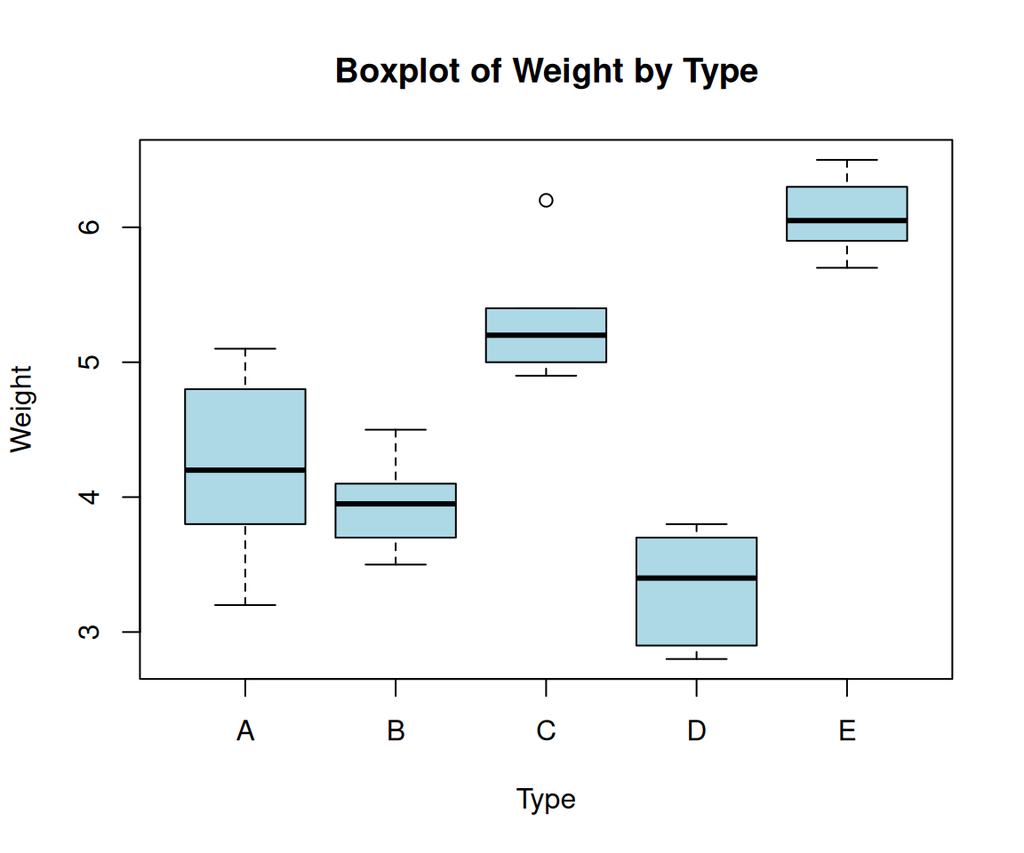

```r
boxplot(weight ~ type,
        col  = "lightblue",
        main = "Boxplot of Weight by Type",
        xlab = "Type",
        ylab = "Weight")
```

If we rearrange the boxplots with the sequence D, B, A, C, E, the pattern becomes more visible:

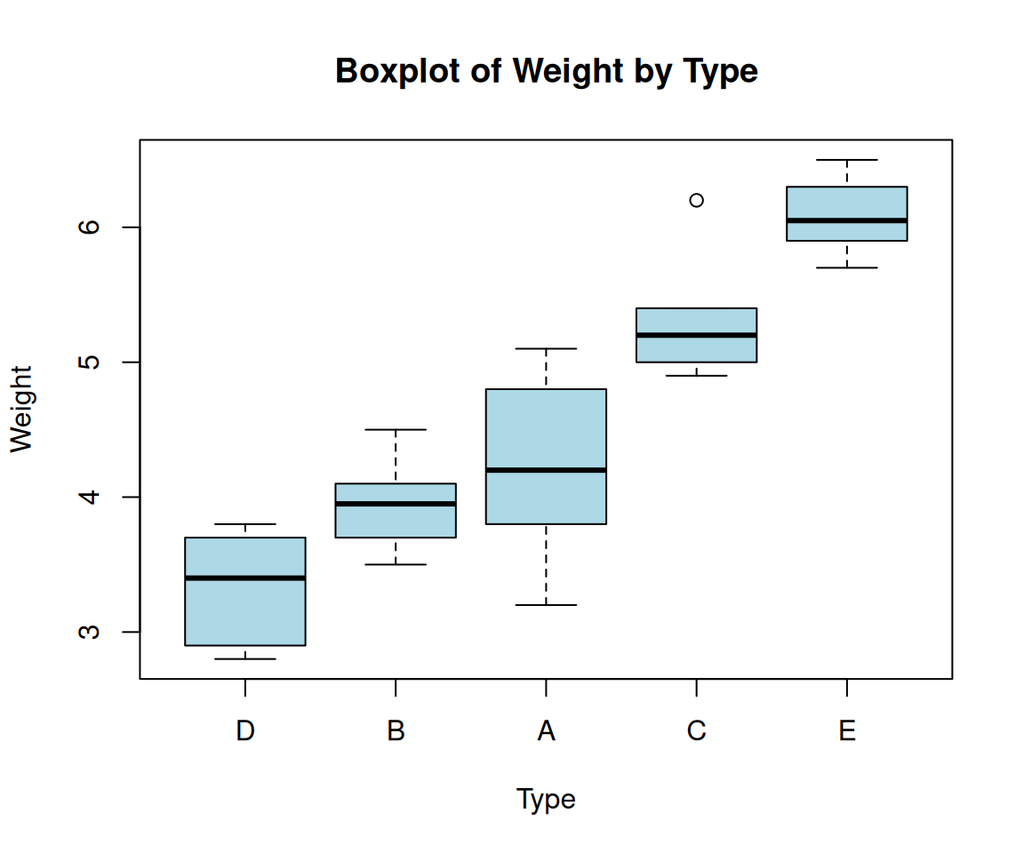

```r
boxplot(weight ~ factor(type, levels=c("D", "B", "A", "C", "E")),
        col  = "lightblue",
        main = "Boxplot of Weight by Type",
        xlab = "Type",
        ylab = "Weight")
```

So the distributions appear to differ across diets: E and C have the highest weight gains, D the lowest, while A and B are in between and overlap. The spreads look roughly similar, though A is somewhat wider and C has one outlier (6.2). We need a formal test to tell whether these differences are significant.

## 1(b): Diet effects

The treatment effects are estimated by the difference between each group mean and the overall mean, $\hat\tau_i = \bar y_{i.} - \bar y_{..}$:

```r
mean <- tapply(weight, type, mean)
effect <- mean - mean(weight)
effect
```

```
##          A          B          C          D          E
## -0.3633333 -0.6300000  0.7366667 -1.2466667  1.5033333
```

## 1(c): Test at $\alpha = 1\%$

We have:
$$\begin{aligned}
H_0 &: \tau_A = \tau_B = \tau_C = \tau_D = \tau_E = 0 \\
H_1 &: \text{at least one } \tau_i \neq 0
\end{aligned}$$

```r
a <- 5;  n <- 6;  N <- a * n

sum_y      <- sum(weight)
sum_y2     <- sum(weight^2)
treat      <- tapply(weight, type, sum)
sum_treat  <- sum(treat)
sum_treat2 <- sum(treat^2)

cf       <- sum_y^2 / N
sst      <- sum_y2 - cf
ss_treat <- sum_treat2 / n - cf
sse      <- sst - ss_treat

ms_treat <- ss_treat / (a - 1)
mse      <- sse / (N - a)
f_calc   <- ms_treat / mse

f_tab <- qf(0.99, df1 = a - 1, df2 = N - a)

c(SS_treat = ss_treat,
  SSE      = sse,
  MS_treat = ms_treat,
  MSE      = mse,
  F_calc   = f_calc,
  F_tab    = f_tab)
```

```
##   SS_treat        SSE   MS_treat        MSE     F_calc      F_tab
## 29.3146667  5.3733333  7.3286667  0.2149333 34.0973945  4.1774202
```

Since $F_{calc} = 34.10 > F_{tab} = 4.18$, we reject the null hypothesis at the 1% level and conclude that at least one diet has a different effect on weight gain.

## 1(d): using aov()

```r
model <- aov(weight ~ type)
summary(model)
```

```
##             Df Sum Sq Mean Sq F value   Pr(>F)
## type         4 29.315   7.329    34.1 8.69e-10 ***
## Residuals   25  5.373   0.215
## ---
## Signif. codes:  0 '***' 0.001 '**' 0.01 '*' 0.05 '.' 0.1 ' ' 1
```

The sums of squares, mean squares and F value match our manual calculation. The p-value ($8.69 \times 10^{-10}$) is far below 0.01, so the conclusion is consistent: we reject $H_0$.

## 1(e): 95% CI for treatment effect of Diet C

For the treatment effect,
$$\hat\tau_C =
\bar y_{C.} - \bar y_{..}$$
with
$$Var(\hat\tau_C) =
\frac{a-1}{a}\cdot\frac{\sigma^2}{n}$$
the interval will be:
$$[\hat\tau_C - t_{\alpha/2,\,N-a}\sqrt{Var(\hat\tau_C)}, \hat\tau_C +
t_{\alpha/2,\,N-a}\sqrt{Var(\hat\tau_C)}]$$

```r
alpha <- 0.05
tcrit <- qt(1 - alpha/2, N - a)
y_c <- mean(weight[type == "C"])
tau_c   <- y_c - mean(weight)
se_tau   <- sqrt((a - 1) / a * mse / n)

c(lower = tau_c - tcrit * se_tau,
  upper = tau_c + tcrit * se_tau)
```

```
##     lower     upper
## 0.3880155 1.0853179
```

The interval [0.39, 1.09] does not contain 0, so Diet C gives significantly more weight gain than the overall average.

## 1(f): Bonferroni pairwise comparisons

Number of comparisons: $r = \binom{5}{2} = 10$

The Bonferroni multiplier is: $t_{\alpha/(2r),\,N-a}$

Two means differ significantly if
$$|\bar
y_i - \bar y_j| > t_{\alpha/(2r),\,N-a}\sqrt{2\,MSE/n}$$

```r
r          <- choose(a, 2)
tcrit_bonf <- qt(1 - alpha / (2 * r), N - a)
b          <- tcrit_bonf * sqrt(2 * mse / n)

pairs <- combn(names(mean), 2)
diff  <- mean[pairs[1, ]] - mean[pairs[2, ]]

data.frame(pair  = paste(pairs[1, ],"-" ,pairs[2, ]),
           diff  = diff,
           lower = diff - b,
           upper = diff + b,
           sig   = ifelse(abs(diff) > b, "*", ""))
```

```
##     pair       diff       lower       upper sig
## 1  A - B  0.2666667 -0.55725897  1.09059231
## 2  A - C -1.1000000 -1.92392564 -0.27607436   *
## 3  A - D  0.8833333  0.05940769  1.70725897   *
## 4  A - E -1.8666667 -2.69059231 -1.04274103   *
## 5  B - C -1.3666667 -2.19059231 -0.54274103   *
## 6  B - D  0.6166667 -0.20725897  1.44059231
## 7  B - E -2.1333333 -2.95725897 -1.30940769   *
## 8  C - D  1.9833333  1.15940769  2.80725897   *
## 9  C - E -0.7666667 -1.59059231  0.05725897
## 10 D - E -2.7500000 -3.57392564 -1.92607436   *
```

At family-wise $\alpha=0.05$, the significant pairs are:

- A - C
- A - D
- A - E
- B - C
- B - E
- C - D
- D - E

The remaining pairs (A - B, B - D, and C - E) are not significant.

## 1(g): Tukey’s Honestly Significant Difference test

```r
TukeyHSD(model, "type", conf.level = 0.95)
```

```
##   Tukey multiple comparisons of means
##     95% family-wise confidence level
##
## Fit: aov(formula = weight ~ type)
##
## $type
##           diff         lwr         upr     p adj
## B-A -0.2666667 -1.05276371  0.51943037 0.8545190
## C-A  1.1000000  0.31390296  1.88609704 0.0031428
## D-A -0.8833333 -1.66943037 -0.09723629 0.0221499
## E-A  1.8666667  1.08056963  2.65276371 0.0000025
## C-B  1.3666667  0.58056963  2.15276371 0.0002537
## D-B -0.6166667 -1.40276371  0.16943037 0.1769390
## E-B  2.1333333  1.34723629  2.91943037 0.0000002
## D-C -1.9833333 -2.76943037 -1.19723629 0.0000009
## E-C  0.7666667 -0.01943037  1.55276371 0.0584445
## E-D  2.7500000  1.96390296  3.53609704 0.0000000
```

At the 5% family-wise level, Tukey’s test finds these significantly different:

- A - C
- A - D
- A - E
- B - C
- B - E
- C - D
- D - E

A - B, B - D, and C - E are not significant. The conclusion agrees with the Bonferroni comparisons.